# Group Project Sep 2022 (Group 14)

Emma Clark, Alice Chen, Kavya Mahesh, Yuqiao Leng, Joël Merki

2022-09-16

# 1 Exploratory Data Analysis

```r
sales <- read.csv("sales.csv")
stores <- read_csv("stores.csv")
details <- read_csv("details.csv")
```

```r
skim(sales)
```

Data summary

| Name | sales |
| --- | --- |
| Number of rows | 421570 |
| Number of columns | 5 |
| _______________________ |  |
| Column type frequency: |  |
| character | 1 |
| logical | 1 |
| numeric | 3 |
| ________________________ |  |
| Group variables | None |

**Variable type: character**

| skim_variable | n_missing | complete_rate | min | max | empty | n_unique | whitespace |
| --- | --- | --- | --- | --- | --- | --- | --- |
| Date | 0 | 1 | 10 | 10 | 0 | 143 | 0 |

**Variable type: logical**

| skim_variable | n_missing | complete_rate | mean | count |
| --- | --- | --- | --- | --- |
| IsHoliday | 0 | 1 | 0.07 | FAL: 391909, TRU: 29661 |

**Variable type: numeric**

| skim_variable | n_missing | complete_rate | mean | sd | p0 | p25 | p50 | p75 | p100 | hist |
| --- | --- | --- | --- | --- | --- | --- | --- | --- | --- | --- |
| Store | 0 | 1 | 22.2 | 12.8 | 1 | 11 | 22 | 33 | 45 | ▇▇▇▇▇ |
| Dept | 0 | 1 | 44.3 | 30.5 | 1 | 18 | 37 | 74 | 99 | ▇▇▅▂▆ |
| Weekly_Sales | 0 | 1 | 16092.7 | 22873.1 | -4991 | 2095 | 7668 | 20337 | 671916 | ▇▁▁▁▁ |

```r
#Changing Date variable from Character to date type:
sales <- sales %>%
  mutate(Date = dmy(Date),
         Store = as.character(Store),
         Dept = as.character(Dept))

head(sales, n=10)
```

```
##    Store Dept       Date IsHoliday Weekly_Sales
## 1      1    1 2010-02-05     FALSE        25355
## 2      1    1 2010-02-12      TRUE        45621
## 3      1    1 2010-02-19     FALSE        43678
## 4      1    1 2010-02-26     FALSE        19192
## 5      1    1 2010-03-05     FALSE        21564
## 6      1    1 2010-03-12     FALSE        21474
## 7      1    1 2010-03-19     FALSE        22396
## 8      1    1 2010-03-26     FALSE        26049
## 9      1    1 2010-04-02     FALSE        55862
## 10     1    1 2010-04-09     FALSE        42932
```

```r
skim(stores)
```

Data summary

| Name | stores |
| --- | --- |
| Number of rows | 45 |
| Number of columns | 3 |
| _______________________ |  |
| Column type frequency: |  |
| character | 1 |
| numeric | 2 |
| ________________________ |  |
| Group variables | None |

**Variable type: character**

| skim_variable | n_missing | complete_rate | min | max | empty | n_unique | whitespace |
| --- | --- | --- | --- | --- | --- | --- | --- |
| Type | 0 | 1 | 1 | 1 | 0 | 3 | 0 |

**Variable type: numeric**

| skim_variable | n_missing | complete_rate | mean | sd | p0 | p25 | p50 | p75 | p100 | hist |
| --- | --- | --- | --- | --- | --- | --- | --- | --- | --- | --- |
| Store | 0 | 1 | 23 | 13.1 | 1 | 12 | 23 | 34 | 45 | ▇▇▇▇▇ |
| Size | 0 | 1 | 130288 | 63825.3 | 34875 | 70713 | 126512 | 202307 | 219622 | ▆▂▅▂▇ |

```r
stores <- stores %>%
  mutate(Store = as.character(Store))

head(stores, n=10)
```

```
## # A tibble: 10 × 3
##    Store Type    Size
##    <chr> <chr>  <dbl>
##  1 1     A     151315
##  2 2     A     202307
##  3 3     B      37392
##  4 4     A     205863
##  5 5     B      34875
##  6 6     A     202505
##  7 7     B      70713
##  8 8     A     155078
##  9 9     B     125833
## 10 10    B     126512
```

```r
glimpse(stores)
```

```
## Rows: 45
## Columns: 3
## $ Store <chr> "1", "2", "3", "4", "5", "6", "7", "8", "9", "10", "11", "12", "…
## $ Type  <chr> "A", "A", "B", "A", "B", "A", "B", "A", "B", "B", "A", "B", "A",…
## $ Size  <dbl> 151315, 202307, 37392, 205863, 34875, 202505, 70713, 155078, 125…
```

```r
skim(details)
```

Data summary

| Name | details |
| --- | --- |
| Number of rows | 8190 |
| Number of columns | 12 |
| _______________________ |  |
| Column type frequency: |  |
| character | 1 |
| logical | 1 |
| numeric | 10 |
| ________________________ |  |
| Group variables | None |

**Variable type: character**

| skim_variable | n_missing | complete_rate | min | max | empty | n_unique | whitespace |
| --- | --- | --- | --- | --- | --- | --- | --- |
| Date | 0 | 1 | 10 | 10 | 0 | 182 | 0 |

**Variable type: logical**

| skim_variable | n_missing | complete_rate | mean | count |
| --- | --- | --- | --- | --- |
| IsHoliday | 0 | 1 | 0.07 | FAL: 7605, TRU: 585 |

**Variable type: numeric**

| skim_variable | n_missing | complete_rate | mean | sd | p0 | p25 | p50 | p75 | p100 | hist |
| --- | --- | --- | --- | --- | --- | --- | --- | --- | --- | --- |
| Store | 0 | 1.00 | 23.00 | 12.99 | 1.00 | 12.00 | 23.00 | 34.00 | 4.50e+01 | ▇▇▇▇▇ |
| Temperature | 0 | 1.00 | 59.36 | 18.68 | -7.29 | 45.90 | 60.71 | 73.88 | 1.02e+02 | ▁▂▆▇▃ |
| Fuel_Price | 0 | 1.00 | 3.41 | 0.43 | 2.47 | 3.04 | 3.51 | 3.74 | 4.47e+00 | ▅▅▇▇▁ |
| MarkDown1 | 4158 | 0.49 | 7032.37 | 9262.75 | -2781.45 | 1577.53 | 4743.58 | 8923.31 | 1.03e+05 | ▇▁▁▁▁ |
| MarkDown2 | 5269 | 0.36 | 3384.18 | 8793.58 | -265.76 | 68.88 | 364.57 | 2153.35 | 1.05e+05 | ▇▁▁▁▁ |
| MarkDown3 | 4577 | 0.44 | 1760.10 | 11276.46 | -179.26 | 6.60 | 36.26 | 163.15 | 1.49e+05 | ▇▁▁▁▁ |
| MarkDown4 | 4726 | 0.42 | 3292.94 | 6792.33 | 0.22 | 304.69 | 1176.42 | 3310.01 | 6.75e+04 | ▇▁▁▁▁ |
| MarkDown5 | 4140 | 0.49 | 4132.22 | 13086.69 | -185.17 | 1440.83 | 2727.14 | 4832.56 | 7.71e+05 | ▇▁▁▁▁ |
| CPI | 585 | 0.93 | 172.46 | 39.74 | 126.06 | 132.36 | 182.76 | 213.93 | 2.29e+02 | ▇▁▁▂▆ |
| Unemployment | 585 | 0.93 | 7.83 | 1.88 | 3.68 | 6.63 | 7.81 | 8.57 | 1.43e+01 | ▂▇▇▁▁ |

```r
#Changing Date variable from Character to date type and replace Markdown NAs with 0
details <- details %>%
  mutate(Date = dmy(Date),
         Store = as.character(Store),
         MarkDown1 = replace_na(MarkDown1, 0),
         MarkDown2 = replace_na(MarkDown2, 0),
         MarkDown3 = replace_na(MarkDown3, 0),
         MarkDown4 = replace_na(MarkDown4, 0),
         MarkDown5 = replace_na(MarkDown5, 0))


glimpse(details)
```

```
## Rows: 8,190
## Columns: 12
## $ Store        <chr> "1", "1", "1", "1", "1", "1", "1", "1", "1", "1", "1", "1…
## $ Date         <date> 2010-02-05, 2010-02-12, 2010-02-19, 2010-02-26, 2010-03-…
## $ Temperature  <dbl> 42.3, 38.5, 39.9, 46.6, 46.5, 57.8, 54.6, 51.5, 62.3, 65.…
## $ Fuel_Price   <dbl> 2.57, 2.55, 2.51, 2.56, 2.62, 2.67, 2.72, 2.73, 2.72, 2.7…
## $ MarkDown1    <dbl> 0, 0, 0, 0, 0, 0, 0, 0, 0, 0, 0, 0, 0, 0, 0, 0, 0, 0, 0, …
## $ MarkDown2    <dbl> 0, 0, 0, 0, 0, 0, 0, 0, 0, 0, 0, 0, 0, 0, 0, 0, 0, 0, 0, …
## $ MarkDown3    <dbl> 0, 0, 0, 0, 0, 0, 0, 0, 0, 0, 0, 0, 0, 0, 0, 0, 0, 0, 0, …
## $ MarkDown4    <dbl> 0, 0, 0, 0, 0, 0, 0, 0, 0, 0, 0, 0, 0, 0, 0, 0, 0, 0, 0, …
## $ MarkDown5    <dbl> 0, 0, 0, 0, 0, 0, 0, 0, 0, 0, 0, 0, 0, 0, 0, 0, 0, 0, 0, …
## $ CPI          <dbl> 211, 211, 211, 211, 211, 211, 211, 211, 211, 211, 210, 21…
## $ Unemployment <dbl> 8.11, 8.11, 8.11, 8.11, 8.11, 8.11, 8.11, 8.11, 7.81, 7.8…
## $ IsHoliday    <lgl> FALSE, TRUE, FALSE, FALSE, FALSE, FALSE, FALSE, FALSE, FA…
```

```r
favstats(~Weekly_Sales, data=sales)
```

```
##    min   Q1 median    Q3    max  mean    sd      n missing
##  -4991 2095   7668 20337 671916 16093 22873 421570       0
```

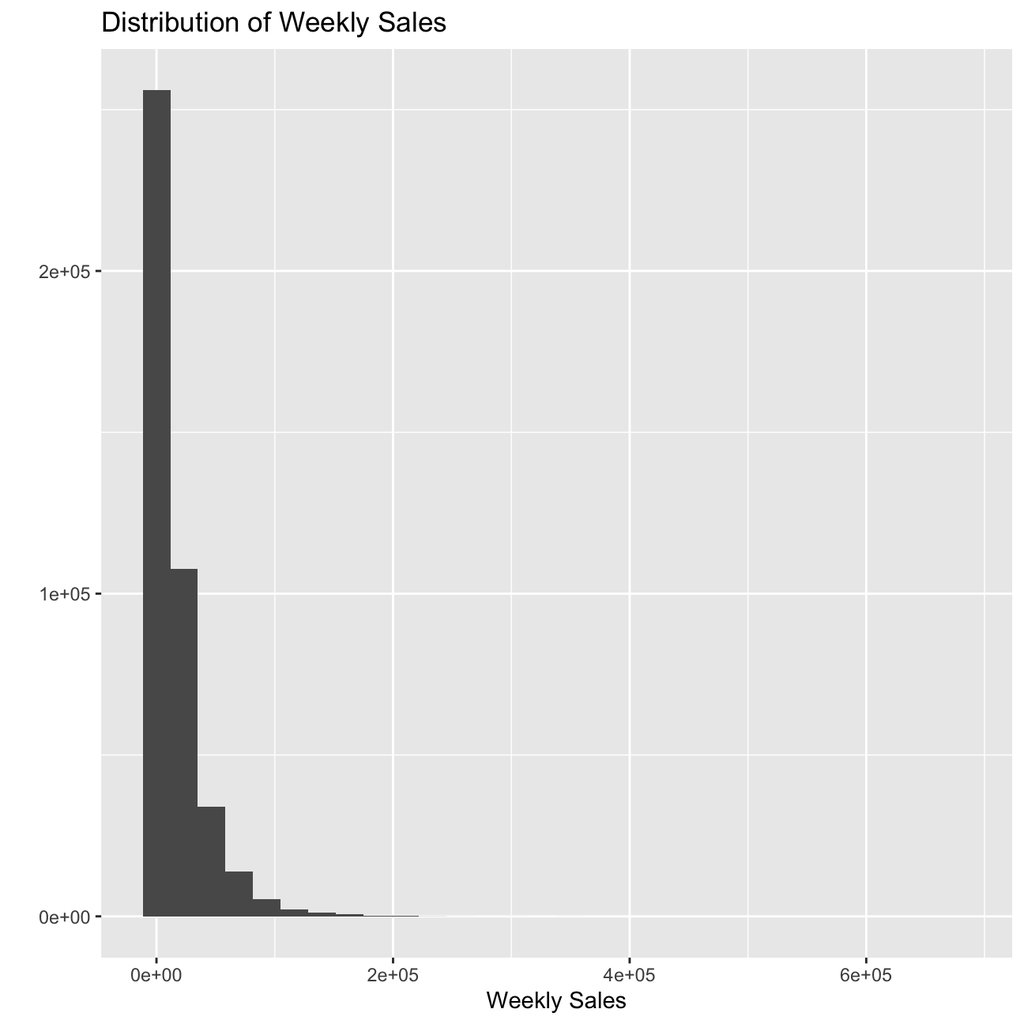

```r
sales %>%
  ggplot(aes(x=Weekly_Sales)) +
  geom_histogram()+
  labs(title= "Distribution of Weekly Sales",
       x="Weekly Sales", y="")
```

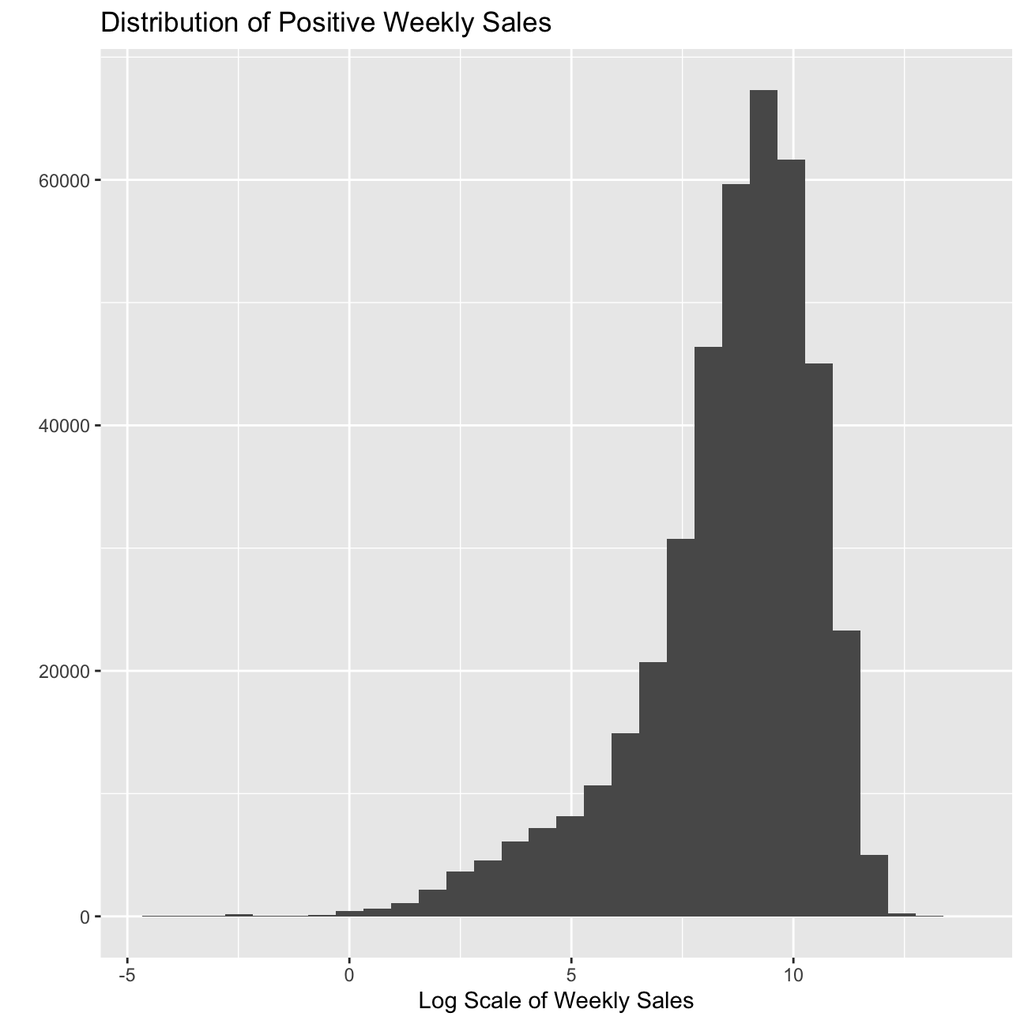

```r
sales %>%
  filter(Weekly_Sales>0) %>%
  mutate(sales_log = log(Weekly_Sales)) %>%
  ggplot(aes(x=sales_log)) +
  geom_histogram()+
   labs(title= "Distribution of Positive Weekly Sales",
       x="Log Scale of Weekly Sales", y="")
```

```r
sales <- sales %>%
  mutate(sales_log =ifelse(Weekly_Sales>0,
                 log(Weekly_Sales),
                 NA))



head(sales, n=10)
```

```
##    Store Dept       Date IsHoliday Weekly_Sales sales_log
## 1      1    1 2010-02-05     FALSE        25355     10.14
## 2      1    1 2010-02-12      TRUE        45621     10.73
## 3      1    1 2010-02-19     FALSE        43678     10.68
## 4      1    1 2010-02-26     FALSE        19192      9.86
## 5      1    1 2010-03-05     FALSE        21564      9.98
## 6      1    1 2010-03-12     FALSE        21474      9.97
## 7      1    1 2010-03-19     FALSE        22396     10.02
## 8      1    1 2010-03-26     FALSE        26049     10.17
## 9      1    1 2010-04-02     FALSE        55862     10.93
## 10     1    1 2010-04-09     FALSE        42932     10.67
```

**Q1**

```r
details_date_count <- details %>%
  summarise(count = n_distinct(Date))

sales_date_count <- sales %>%
  summarise(count = n_distinct(Date))

#How many more weeks of data in details compared to sales:
details_date_count - sales_date_count
```

```
##   count
## 1    39
```

> **There are 39 more weeks of data in details compared to sales**

**Q2**

```r
sales_date_range <- sales %>%
  summarise(minDate = min(Date),
            maxDate = max(Date) ,
            date_range_days = maxDate - minDate +6) %>%
  mutate (diff = difftime(maxDate, minDate, units = "weeks") + 1)

sales_date_range
```

```
##      minDate    maxDate date_range_days      diff
## 1 2010-02-05 2012-10-26       1000 days 143 weeks
```

> **A2: We calculated the date range by subtracting the smallest given date from the largest given date, to which we added another 6 days, as the dates indicated the first day of the week to which the data is attributed.**

**Q3**

```r
sales %>%
  group_by(Store) %>%
  summarise(number_of_dept = n_distinct(Dept)) %>%
  arrange(desc(number_of_dept)) %>%
  head(n=3)
```

```
## # A tibble: 3 × 2
##   Store number_of_dept
##   <chr>          <int>
## 1 13                79
## 2 15                79
## 3 19                79
```

> **Max Departments in a single store: 79**

**Q4**

```r
# Joining "store" with "sales" to further analyse the data within each store type

sales_stores_details <- sales %>%
  inner_join(stores, on="Store") %>%
  inner_join(details[, c('Store','Date','Temperature','Fuel_Price','CPI','Unemployment','IsHoliday' )],
             on = c('Store','Date'))

head(sales_stores_details, n=10)
```

```
##    Store Dept       Date IsHoliday Weekly_Sales sales_log Type   Size
## 1      1    1 2010-02-05     FALSE        25355     10.14    A 151315
## 2      1    1 2010-02-12      TRUE        45621     10.73    A 151315
## 3      1    1 2010-02-19     FALSE        43678     10.68    A 151315
## 4      1    1 2010-02-26     FALSE        19192      9.86    A 151315
## 5      1    1 2010-03-05     FALSE        21564      9.98    A 151315
## 6      1    1 2010-03-12     FALSE        21474      9.97    A 151315
## 7      1    1 2010-03-19     FALSE        22396     10.02    A 151315
## 8      1    1 2010-03-26     FALSE        26049     10.17    A 151315
## 9      1    1 2010-04-02     FALSE        55862     10.93    A 151315
## 10     1    1 2010-04-09     FALSE        42932     10.67    A 151315
##    Temperature Fuel_Price CPI Unemployment
## 1         42.3       2.57 211         8.11
## 2         38.5       2.55 211         8.11
## 3         39.9       2.51 211         8.11
## 4         46.6       2.56 211         8.11
## 5         46.5       2.62 211         8.11
## 6         57.8       2.67 211         8.11
## 7         54.6       2.72 211         8.11
## 8         51.5       2.73 211         8.11
## 9         62.3       2.72 211         7.81
## 10        65.9       2.77 211         7.81
```

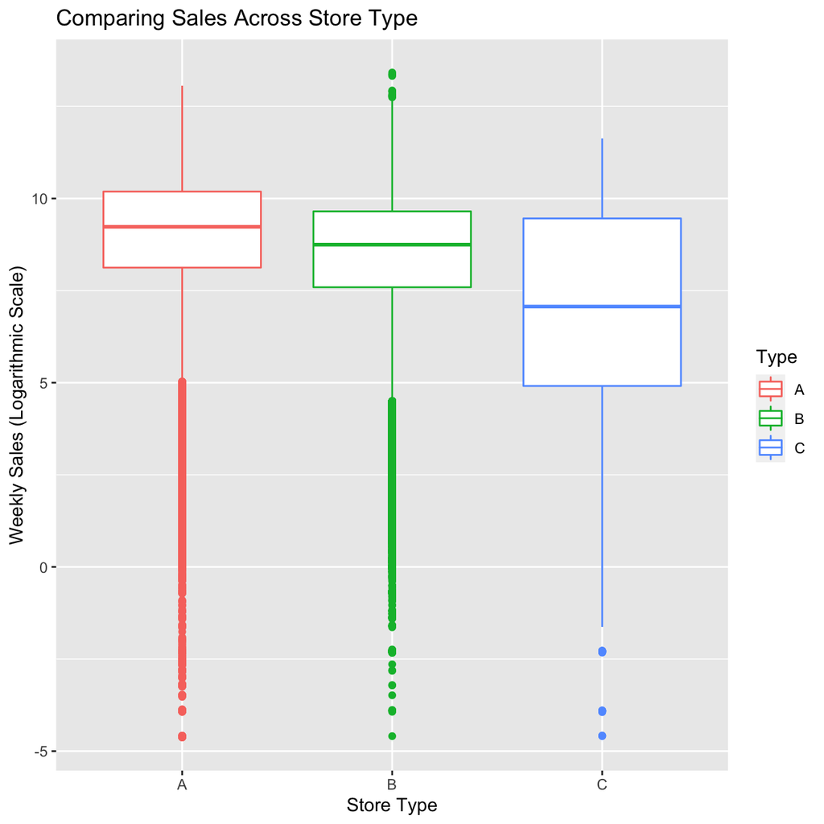

```r
# Plotting the weekly sales on a logarithmic scale by store type

sales_stores_details %>%
  ggplot(aes(x= Type,
             #we used the weekly sales log so the scale would be easier to comprehend
             y=sales_log,
             color = Type,
             na.rm=TRUE)) +
  geom_boxplot()+
  labs(title="Comparing Sales Across Store Type",
       x="Store Type",
       y="Weekly Sales (Logarithmic Scale)")
```

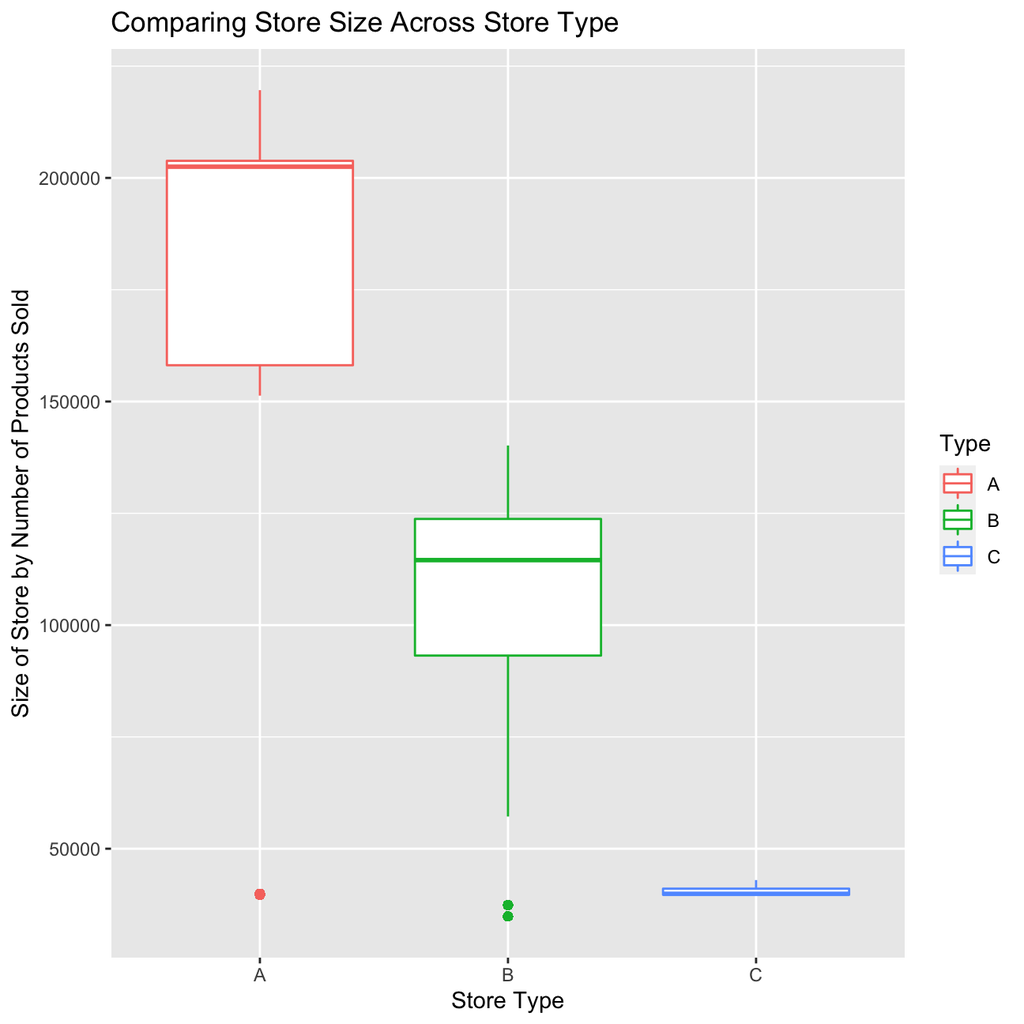

```r
# Plotting size by store type

sales_stores_details %>%
  ggplot(aes(x= Type, y=Size, color = Type, na.rm=TRUE)) +
  geom_boxplot()+
   labs(title="Comparing Store Size Across Store Type",
       x="Store Type",
       y="Size of Store by Number of Products Sold")
```

> **We joined together information from sales and stores to inspect if there was any significant correlation between store type and weekly sales or size. We found that Type A, B, C seems to be in reference to the size of the store as indicated by the boxplot above. The stores with the largest size are categorized as Type A, the medium sized stores are categorized as Type B, and the smallest sized stores are categorized as Type C.**

**Q5**

```r
sales %>%
  filter(Date >= as.Date('2011/01/07') & Date <= as.Date('2011/12/30') ) %>%
  group_by(Store) %>%
  summarise(total_sales = sum(Weekly_Sales),
            mean_sales = mean(Weekly_Sales)) %>%
  arrange(desc(total_sales))
```

```
## # A tibble: 45 × 3
##    Store total_sales mean_sales
##    <chr>       <dbl>      <dbl>
##  1 4      111857114.     30037.
##  2 20     110552711.     29655.
##  3 14     106780833.     29303.
##  4 13     105233983.     27657.
##  5 10      99594226.     26580.
##  6 2       99271930.     26622.
##  7 27      92545861.     24825.
##  8 1       81477648.     21867.
##  9 6       81167520.     21778.
## 10 39      76272734.     21240.
## # … with 35 more rows
```

> **Store 4 had the maximum sales in the given date range with mean weekly sales of about $30,037.**

**Q6**

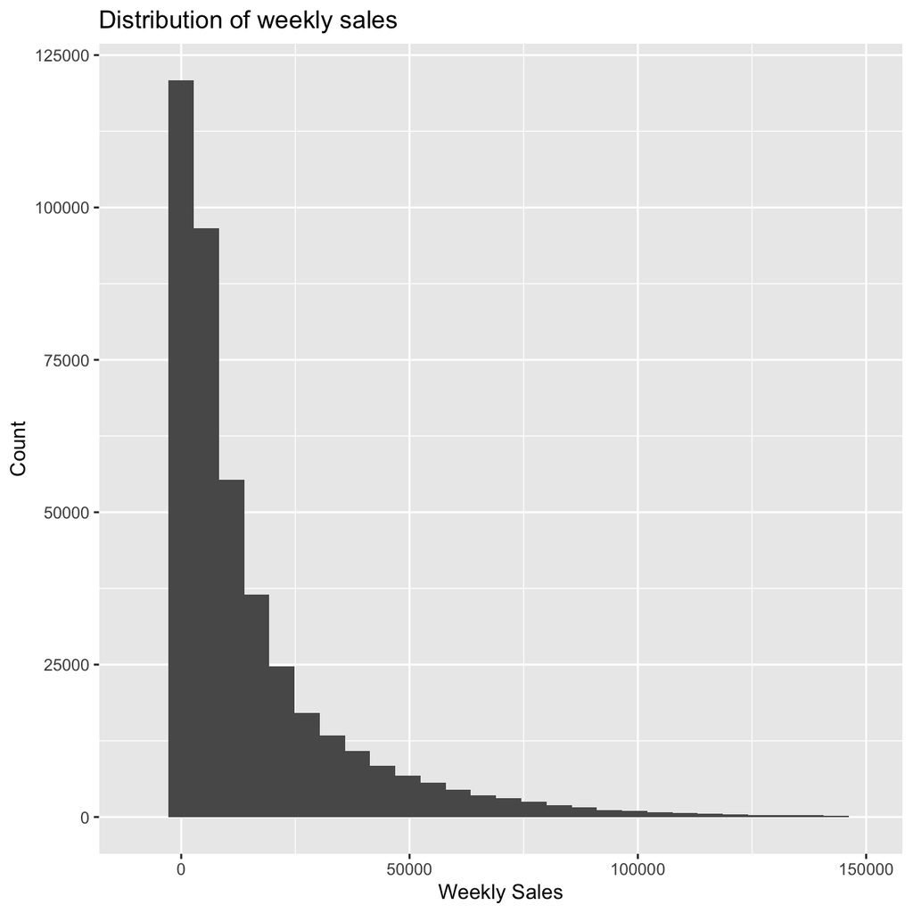

```r
# Histogram to look at distribution of weekly sales. Weekly sales were negative for a few weeks so we tried looking at the distribution for only positive values.
sales %>%
  filter(Weekly_Sales>0) %>%
  ggplot(aes(x = Weekly_Sales)) +
  geom_histogram() +
  #Added limits to view values around 0
  xlim(-10000,150000) +
    labs(title="Distribution of weekly sales",
       x="Weekly Sales",
       y="Count")
```

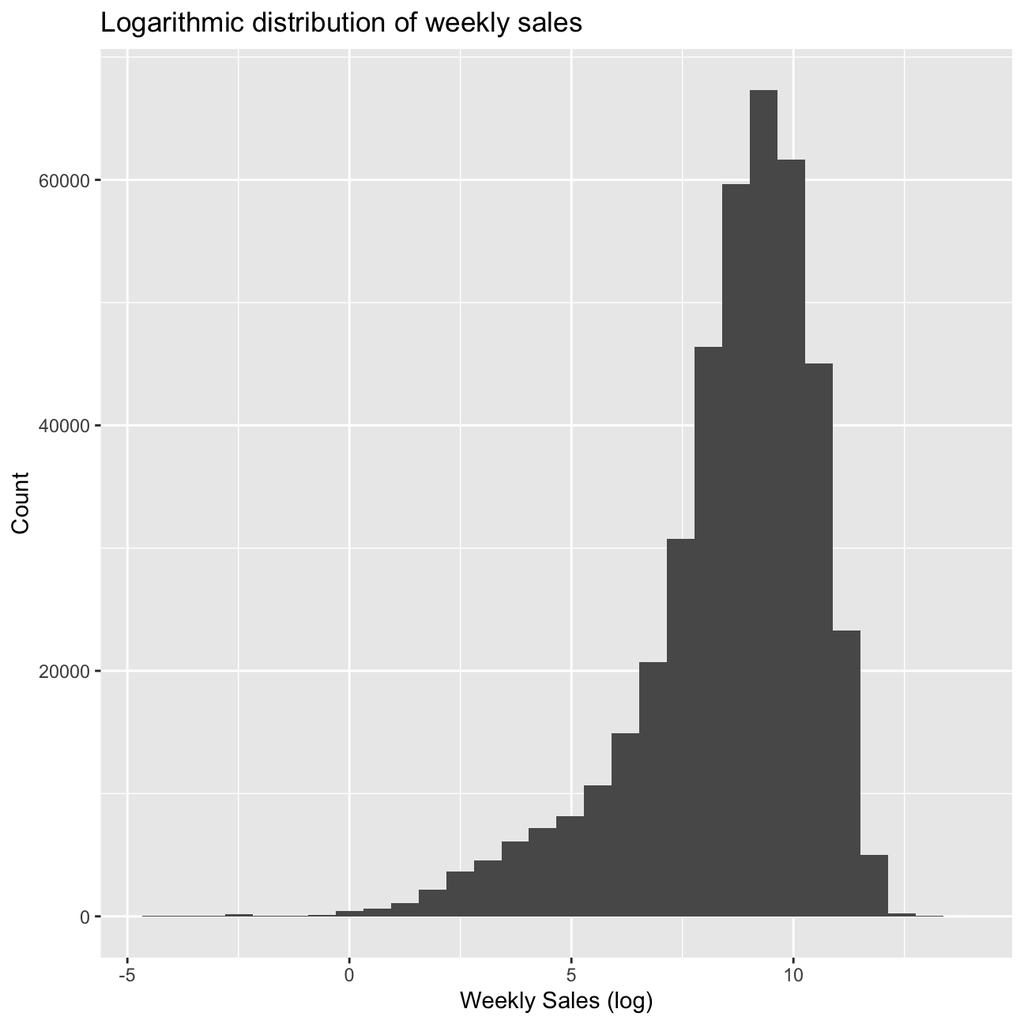

```r
#Calculation log of weekly sales excluding negative weekly sales values
sales %>%
  filter(Weekly_Sales>0) %>%
  mutate(sales_log = log(Weekly_Sales)) %>%
  ggplot(aes(x=sales_log)) +
  geom_histogram() +
      labs(title="Logarithmic distribution of weekly sales",
       x="Weekly Sales (log)",
       y="Count")
```

> **The distribution of weekly sales is right skewed. We then looked at the distribution of the log of weekly sales (only focusing on positive values), which gives a left skewed distribution.**

**Looking at Distribution of sales by store:**

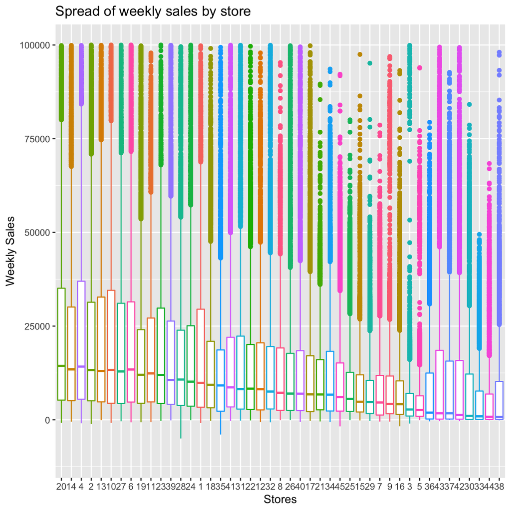

```r
sales %>%
  ggplot(aes(x=fct_reorder(Store, Weekly_Sales, .desc=TRUE) ,
             y=Weekly_Sales,
             color=Store,
             na.rm=TRUE)) +
  geom_boxplot() +
  theme(legend.position = "none") +
  ylim(-10000,100000) +
      labs(title="Spread of weekly sales by store",
       x="Stores",
       y="Weekly Sales")
```

**Q7**

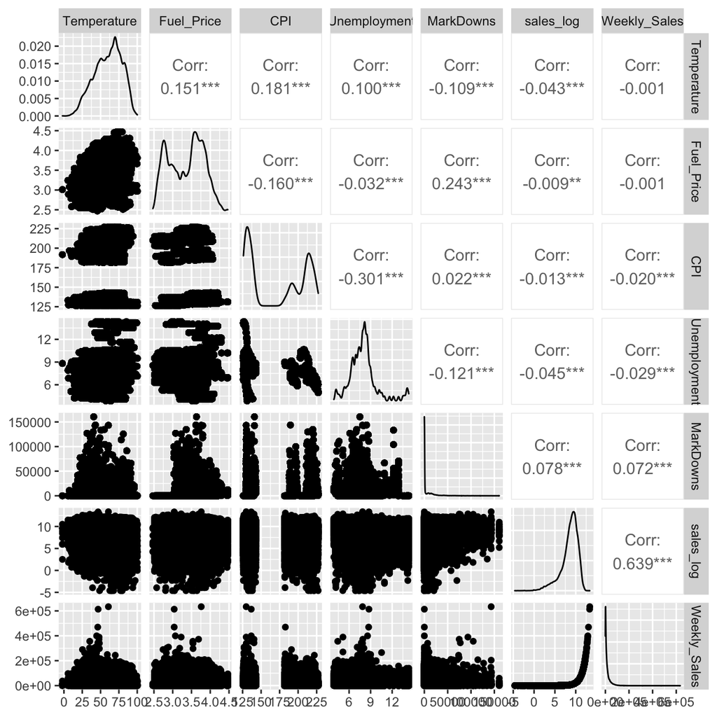

```r
sales_subset <- sales[sample(nrow(sales), size=100000), ]

#Method 1 - ggpairs
sales_subset %>%
  left_join(details, on = c("Store","Date")) %>%

  #We calculated the sum of dmarkdown columns (cumulative effect of different promotions)
  mutate(MarkDowns = MarkDown1 + MarkDown2 + MarkDown3 + MarkDown4 + MarkDown5) %>%
  select(Temperature, Fuel_Price, CPI, Unemployment, MarkDowns, sales_log, Weekly_Sales) %>%
  ggpairs()
```

```r
#Method 2 - using cor()
sales_details <- sales %>%
  left_join(details, on = c("Store","Date")) %>%
  mutate(MarkDowns = MarkDown1 + MarkDown2 + MarkDown3 + MarkDown4 + MarkDown5)

cor(as.matrix(select( sales_details, Weekly_Sales, Temperature, Fuel_Price, CPI, Unemployment,
                      MarkDowns)))
```

```
##              Weekly_Sales Temperature Fuel_Price     CPI Unemployment MarkDowns
## Weekly_Sales     1.000000     -0.0023  -0.000116 -0.0209      -0.0259    0.0652
## Temperature     -0.002299      1.0000   0.143859  0.1821       0.0967   -0.1113
## Fuel_Price      -0.000116      0.1439   1.000000 -0.1642      -0.0339    0.2443
## CPI             -0.020941      0.1821  -0.164210  1.0000      -0.3000    0.0199
## Unemployment    -0.025909      0.0967  -0.033853 -0.3000       1.0000   -0.1188
## MarkDowns        0.065249     -0.1113   0.244348  0.0199      -0.1188    1.0000
```

```r
#Running cor() withput mutating new column for sum of Markdowns
cor(as.matrix(select( sales_details, Weekly_Sales, Temperature, Fuel_Price, CPI, Unemployment,
                      MarkDown1, MarkDown2, MarkDown3, MarkDown4, MarkDown5)))
```

```
##              Weekly_Sales Temperature Fuel_Price      CPI Unemployment
## Weekly_Sales     1.000000     -0.0023  -0.000116 -0.02094      -0.0259
## Temperature     -0.002299      1.0000   0.143859  0.18211       0.0967
## Fuel_Price      -0.000116      0.1439   1.000000 -0.16421      -0.0339
## CPI             -0.020941      0.1821  -0.164210  1.00000      -0.3000
## Unemployment    -0.025909      0.0967  -0.033853 -0.29995       1.0000
## MarkDown1        0.047231     -0.0264   0.297056  0.01091      -0.1052
## MarkDown2        0.020738     -0.1797   0.029153 -0.00355      -0.0414
## MarkDown3        0.038528     -0.0560   0.018615 -0.00584      -0.0181
## MarkDown4        0.037473     -0.0503   0.166622 -0.00205      -0.0765
## MarkDown5        0.050438     -0.0148   0.215420  0.06791      -0.1204
##              MarkDown1 MarkDown2 MarkDown3 MarkDown4 MarkDown5
## Weekly_Sales    0.0472   0.02074   0.03853   0.03747    0.0504
## Temperature    -0.0264  -0.17967  -0.05603  -0.05028   -0.0148
## Fuel_Price      0.2971   0.02915   0.01861   0.16662    0.2154
## CPI             0.0109  -0.00355  -0.00584  -0.00205    0.0679
## Unemployment   -0.1052  -0.04143  -0.01808  -0.07651   -0.1204
## MarkDown1       1.0000   0.17487  -0.01441   0.83890    0.4151
## MarkDown2       0.1749   1.00000  -0.00608   0.11325    0.1317
## MarkDown3      -0.0144  -0.00608   1.00000  -0.01202    0.0425
## MarkDown4       0.8389   0.11325  -0.01202   1.00000    0.3034
## MarkDown5       0.4151   0.13174   0.04247   0.30337    1.0000
```

> **The cumulative effect of Markdowns has the highest correlation with weekly sales. However, the value is very small (6.5%). If we do not calculate the cumulative effect of Markdowns, then Markdown5 has the highest correlation to weekly sales (around 5%)**

**Q8 Stores with mean weekly sales during holiday weeks lesser than normal weeks**

```r
sales %>%
  group_by(Store, IsHoliday) %>%
  summarise(mean_weekly_sales = mean(Weekly_Sales)) %>%
  pivot_wider(names_from = IsHoliday, values_from = mean_weekly_sales) %>%
  rename(Holiday = "TRUE",
         Normal = "FALSE") %>%
  mutate(Holiday_lesser = ifelse(Holiday < Normal, 1, 0)) %>%
  filter(Holiday_lesser == 1)
```

```
## # A tibble: 5 × 4
## # Groups:   Store [5]
##   Store Normal Holiday Holiday_lesser
##   <chr>  <dbl>   <dbl>          <dbl>
## 1 30     8831.   8805.              1
## 2 36     8657.   8476.              1
## 3 37    10372.  10256.              1
## 4 38     7544.   7532.              1
## 5 44     6086.   5957.              1
```

> **There are 5 stores where the mean sales during holiday weeks was less than normal weeks (Stores: 30, 36, 37, 38, 44)**

**Q9 Stores with median weekly sales during holiday weeks lesser than normal weeks**

```r
sales %>%
  group_by(Store, IsHoliday) %>%
  summarise(med_weekly_sales = median(Weekly_Sales)) %>%
  pivot_wider(names_from = IsHoliday, values_from = med_weekly_sales) %>%
  rename(Holiday = "TRUE",
         Normal = "FALSE") %>%
  mutate(Holiday_lesser = ifelse(Holiday < Normal, 1, 0)) %>%
  filter(Holiday_lesser == 1)
```

```
## # A tibble: 4 × 4
## # Groups:   Store [4]
##   Store Normal Holiday Holiday_lesser
##   <chr>  <dbl>   <dbl>          <dbl>
## 1 16     4175.   4126.              1
## 2 17     6799.   6572.              1
## 3 25     5592.   5563.              1
## 4 32     7637.   7504.              1
```

# 2 Inferential Statistics

```r
#Converting Store type to numeric variable
stores %>%
  mutate(Type = as.numeric(as.factor(Type)))
```

```
## # A tibble: 45 × 3
##    Store  Type   Size
##    <chr> <dbl>  <dbl>
##  1 1         1 151315
##  2 2         1 202307
##  3 3         2  37392
##  4 4         1 205863
##  5 5         2  34875
##  6 6         1 202505
##  7 7         2  70713
##  8 8         1 155078
##  9 9         2 125833
## 10 10        2 126512
## # … with 35 more rows
```

```r
sales_holiday <- sales %>%
  group_by(Store,Date,IsHoliday) %>%
  summarise(sum_weekly_sales = sum(Weekly_Sales)) %>%
  mutate(holiday = case_when(month(Date) == 12 & IsHoliday == TRUE  ~ "Christmas",
    month(Date) == 2  & IsHoliday == TRUE ~ "SuperBowl",
    month(Date) == 11  & IsHoliday == TRUE ~ "Thanksgiving",
    month(Date) == 9 & IsHoliday == TRUE ~ "LaborDay",
    TRUE ~ "non_holiday"))

head(sales_holiday, n=5)
```

```
## # A tibble: 5 × 5
## # Groups:   Store, Date [5]
##   Store Date       IsHoliday sum_weekly_sales holiday
##   <chr> <date>     <lgl>                <dbl> <chr>
## 1 1     2010-02-05 FALSE             1654088. non_holiday
## 2 1     2010-02-12 TRUE              1650933. SuperBowl
## 3 1     2010-02-19 FALSE             1628874. non_holiday
## 4 1     2010-02-26 FALSE             1429147. non_holiday
## 5 1     2010-03-05 FALSE             1563790. non_holiday
```

## 2.1 Part B Inferential Stats

```r
#Q1.a

#Avg weekly sales for each holiday
data_holiday <- sales_holiday %>%
  filter(IsHoliday == TRUE) %>%
  group_by(holiday) %>%
  summarise(avg_sales = mean(sum_weekly_sales))

data_holiday
```

```
## # A tibble: 4 × 2
##   holiday      avg_sales
##   <chr>            <dbl>
## 1 Christmas      967495.
## 2 LaborDay      1049848.
## 3 SuperBowl     1086856.
## 4 Thanksgiving  1480632.
```

```r
#Holiday with highest Avg Sales
holiday <- data_holiday %>%
  slice_max(avg_sales, n = 1)
holiday
```

```
## # A tibble: 1 × 2
##   holiday      avg_sales
##   <chr>            <dbl>
## 1 Thanksgiving  1480632.
```

> **It appears that the holiday with the highest average weekly sales is Thanksgiving**

```r
#Q 1.b

comparison <- data_holiday %>%
  filter(holiday %in% c("LaborDay","Thanksgiving")) %>%
  arrange(desc(avg_sales))

#Q1 B - How much more value ($, in total for all stores) is generated during the average week in the holiday given in a) compared to Labor Day?
difference <- diff(-comparison$avg_sales)
difference
```

```
## [1] 430784
```

```r
#calculating percentage increase
Thanksgiving_avgsales <- comparison %>%
  filter(holiday == 'LaborDay') %>%
  select(avg_sales)

(diff(-comparison$avg_sales)) / Thanksgiving_avgsales * 100
```

```
##   avg_sales
## 1        41
```

```r
# The difference between average weekly sales for Labor Day and Thanksgiving (in total for all stores) is $430,784, which is 41% higher compared to Labor Day
```

**Q2 - Hypothesis test to check if there is a significant difference in weekly sales during holiday and normal weeks (excluding Thanksgiving)**

```r
# H0: There is no difference in weekly sales on holiday weeks compared to non-holiday weeks.
# v.s.
# H1: There is difference in weekly sales on holiday weeks compared to non-holiday weeks.


#Creating column with the holiday name:
holiday_sales_data <- sales %>%
  mutate(holiday = case_when(month(Date) == 12 & IsHoliday == TRUE  ~ "Christmas",
    month(Date) == 2  & IsHoliday == TRUE ~ "SuperBowl",
    month(Date) == 11  & IsHoliday == TRUE ~ "Thanksgiving",
    month(Date) == 9 & IsHoliday == TRUE ~ "LaborDay",
    TRUE ~ "non_holiday"))

#Filtering out Thanksgiving rows
non_thanksgiving_sales <- holiday_sales_data %>%
  filter(holiday != "Thanksgiving")
```

Running a t-test:

```r
t.test(Weekly_Sales ~ IsHoliday, data = non_thanksgiving_sales)
```

```
##
##  Welch Two Sample t-test
##
## data:  Weekly_Sales by IsHoliday
## t = 1, df = 26693, p-value = 0.3
## alternative hypothesis: true difference in means between group FALSE and group TRUE is not equal to 0
## 95 percent confidence interval:
##  -124  462
## sample estimates:
## mean in group FALSE  mean in group TRUE
##               16012               15844
```

> **The t test shows that the p-value is 0.26 and t value is 1.13, which means that we fail to reject the Null hypothesis. The 95% confidence interval is [-124,462] which contains zero. It means that we cannot say that there is a significant difference in weekly sales on holiday weeks compared to non-holiday weeks if we exclude Thanksgiving as a holiday.**